# Happiness Economics - Group: Romania

Sören Schwabbauer, David Hollenstein, Alexander Hanser, Jürgen Bildstein

# 1 Download data

> Download the data for the country you choose. You also find the official variable description file in the corresponding folder. Done.

# 2 First overview of data

> Get acquainted with the data (rename and/or recode variables). The main variables with which we are going to work are measures of subjective well-being (SWB), namely general happiness and life satisfaction. Are these two variables comparable measures of SWB? How do these variables correlate with personal characteristics like income, health, age, marital status, etc.? Find suitable ways to show some possible (not necessarily causal) relationships. ## A170 satisfaction in life

```
##    Min. 1st Qu.  Median    Mean 3rd Qu.    Max.
##   1.000   6.000   8.000   7.528   9.000  10.000
```

The summary command allows us to have a rough overview of the variable A170 - satisfaction in life. The variable is scaled from 1 to 10, with 10 being the highest level of satisfaction. Since one can rank the level of satisfaction (e.g: a level of 8 being higher ranked than a level 2), but the distance between the levels is subjective (e.g: a person on a level 8 is not necessarily twice as happy as a person on the level 4) Life satisfaction can be considered an ordinarily scaled variable. The summary command shows, that everybody has replied to to questions (no NA’s). Another conclusion which can be drawn from the summary command is the average level of satisfaction. With a median level of 8, and a mean of 7.5, the Romanian people are generally not extremely satisfied, but also not unsatisfied with their life as a whole. In addition to that, it can be seen, that the half of the asked population ranks themselves between a 6 and a 9.

The following plot allows a look at the distribution of satisfaction

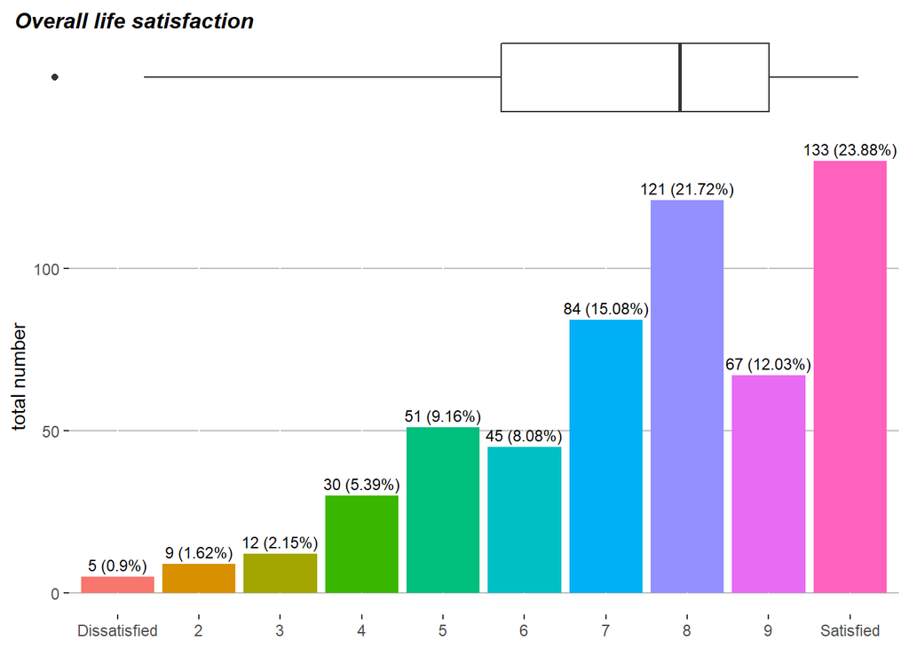

The barplot on the distribution of satisfaction in life adds additional information to the summary command. As one can see, most people can identify with the highest level “satisfied” . It remains unclear, why there is such a rapid drop one level below. Furthermore it can be seen, that the lower 25% are much more distributed (from 2 to 5), whereas “Satisfied” contains all the upper 25% of the counts.

## 2.1 A008 Feeling of happiness

```
##    Min. 1st Qu.  Median    Mean 3rd Qu.    Max.
##   1.000   3.000   3.000   2.962   3.000   4.000
```

The following barplot allows a closer look at the distribution of happiness within # the questioned people in Romania

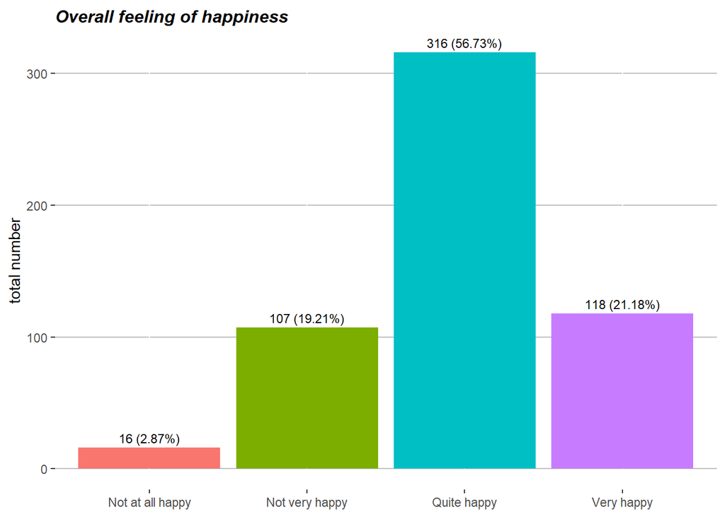

From the barplot one can conclude, that most people (approx. 56%) are “quite happy”, one fifth of the questioned population are “very happy” and roughly the same amount of people are “not very happy”, or “not at all happy”

## 2.2 Univariate and multivariate analysis of SWB Factors

In the following section we are going to provide a comparison of the two key variables with other variables.

### 2.2.1 Income

```
##    Min. 1st Qu.  Median    Mean 3rd Qu.    Max.
##   1.000   3.000   4.000   3.867   5.000  10.000
```

The variable income was evaluated by showing the questioned households a range of income groups within their country, of which the participants had to select one. The income then got scaled from 1 (the 1st decile) and 10 (the highest decile).

The following two plots allow an insight in the income distribution of Romania

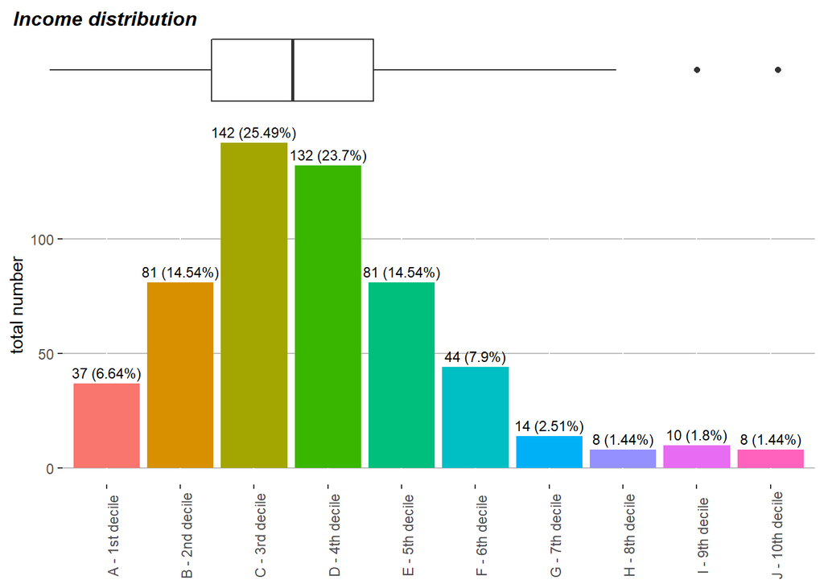

It can be seen, that the distribution is right skewed. This indicates, that the vast majority belongs to a lower income group. The boxplot shows, that 50% of the people lay in between the 3rd and the 5th decile.

The following mosaic plots shall provide an overview of the two main variables and the scaled income.

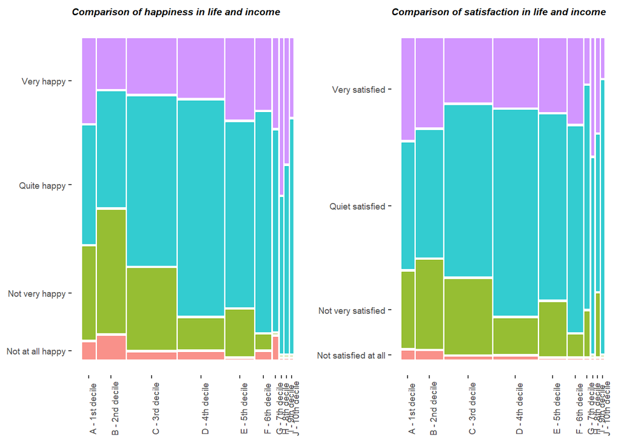

For a better overview, we grouped the levels of satisfaction into 1 = “Not satisfied at all, 2-5 =”not very satisfied”, 6-9 = “quiet satisfied” and 10 = very satisfied.Comparing the satisfaction and the income, the group with the lowest income, again has one of the highest rates of satisfaction. Tough it should also be mentioned, that they also share one of the highest rates of Dissatisfaction. Once again it shows, that a higher income rules out the chance of being “not satisfied at all”. At the same time, the top 10% income group accounts for the lowest amount of very satisfied people.

### 2.2.2 Health

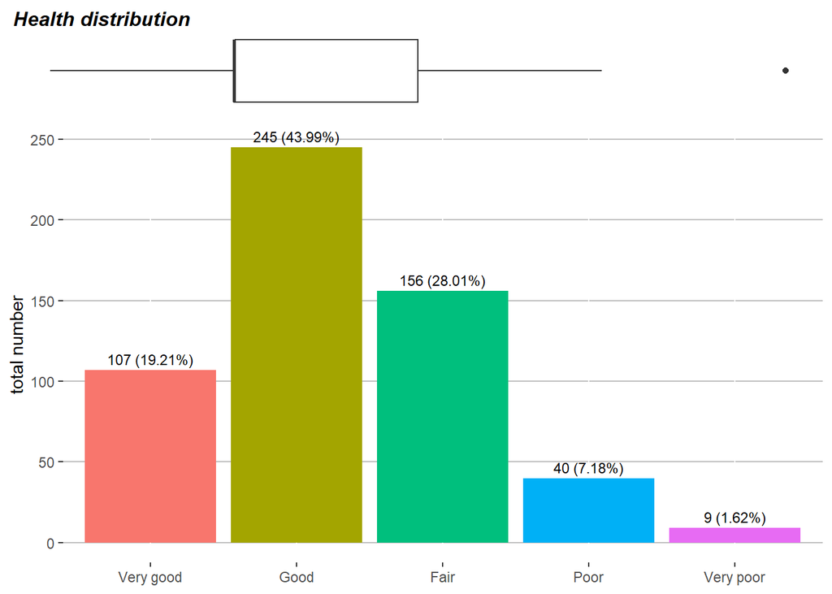

The average citizen seems to be in rather good health condition. Most of the answers group around the “good” health answer. The second most frequent answer is the “fair” health response. A very small percentage of respondents report being of “poor” or “very poor” health.

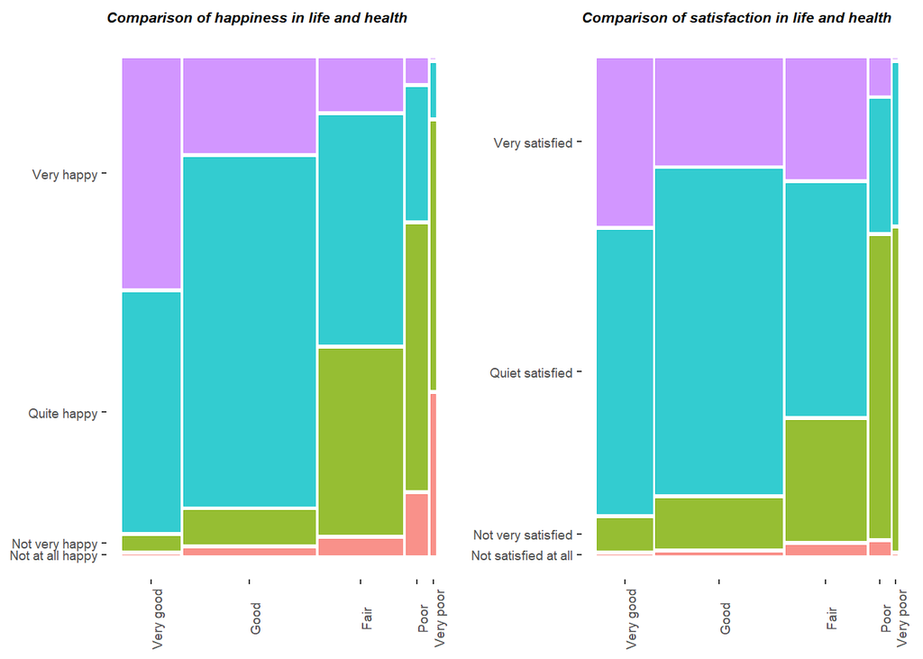

These mosaic plots show a connection between health of an individual and the satisfaction with life and overall happiness. Looking at happiness in life first, what stands out is, that those with poor and very poor health are to a large extent not very happy. This also translates to overall life satisfaction. Those with poor health are to a large extent not very satisfied. The opposite to this observation also holds true. Those with good and very good health are to a very large extent either very happy or quite happy. Respectively, those with good and very good health are also quite satisfied and very satisfied.

### 2.2.3 Age

```
##    Min. 1st Qu.  Median    Mean 3rd Qu.    Max.
##   19.00   34.00   50.00   49.54   65.00   82.00
```

The summary command tells us the mean and the median age. Bothe are around 50. With the mean and the median age laying close together, one can say, that the distribution is rater equal. Since the age scaling end at the age of 82, one can not say, how old the oldest person in the dataframe is. The youngest however is at the age of 19.

In order to get a brief overview of the age distribution, a population pyramid can help.

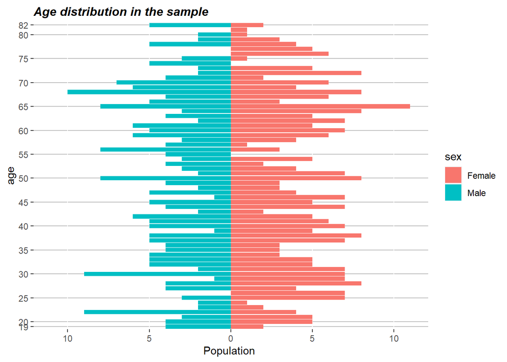

The visualisation of age distribution separated by sex supports the insight, that there is no significant difference or trend in age distribution.

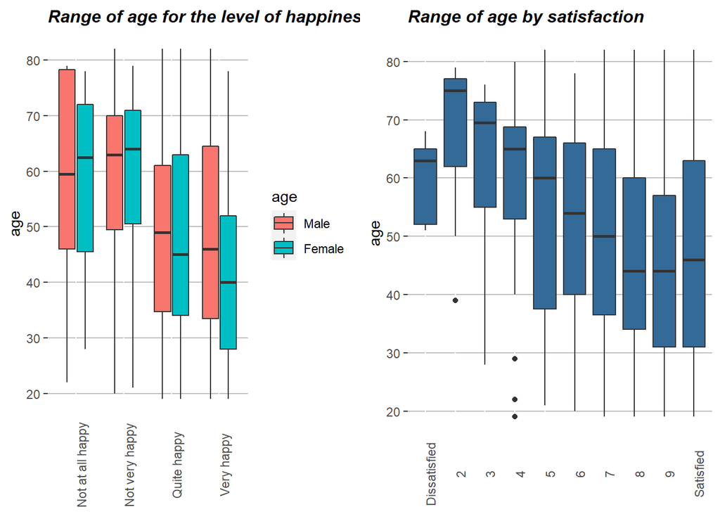

### 2.2.4 Marital status

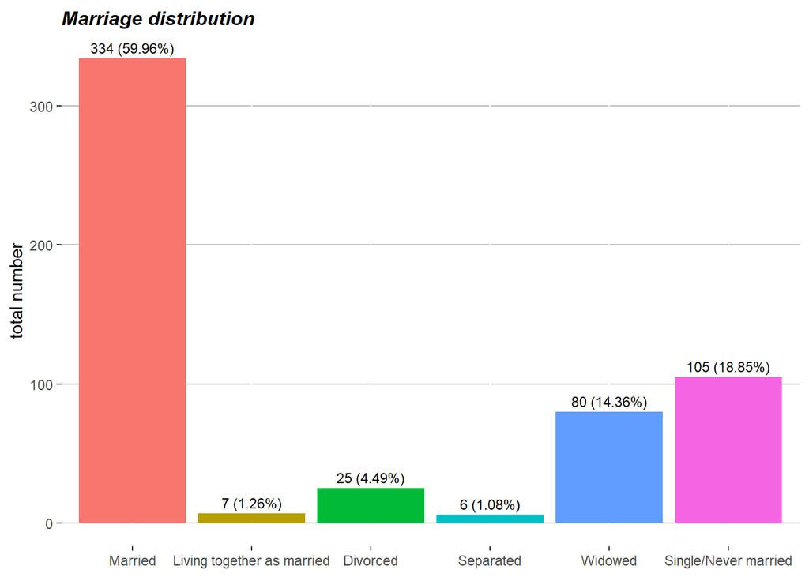

Since it is not possible, to put the marital status in some kind of hierarchy, it can be considered a nominal scaled variable. The graph shows the distribution of people regarding their legal marital status. It can be seen, that the wide majority (60%) is married. The second and third highest population is formed by people who are single or have never been married (19%), and people who are widowed (15%).

The following mosaic plots are an attempt of a causal link between the marriage status, happiness and life satisfaction

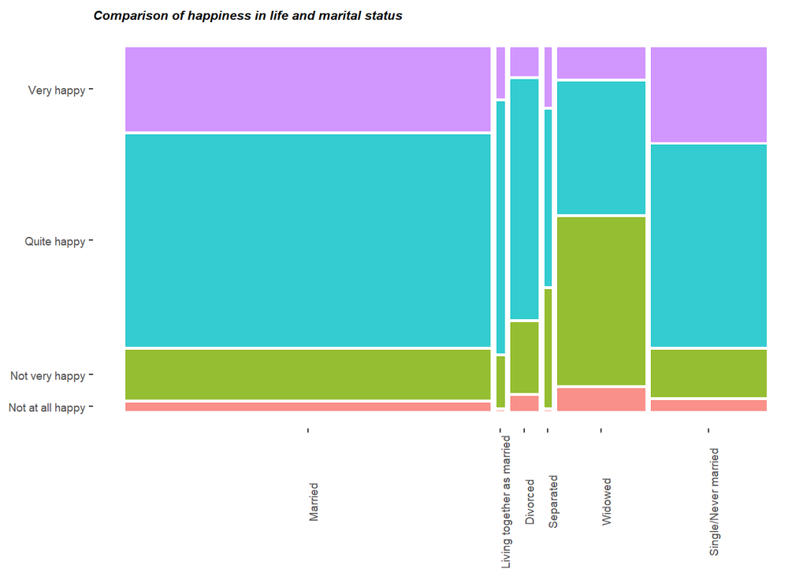

It can be seen, that the widowed people are generally the ones who are rather not, or not happy at all. The single and married people are generally the biggest peopulation of people who are “very happy”.

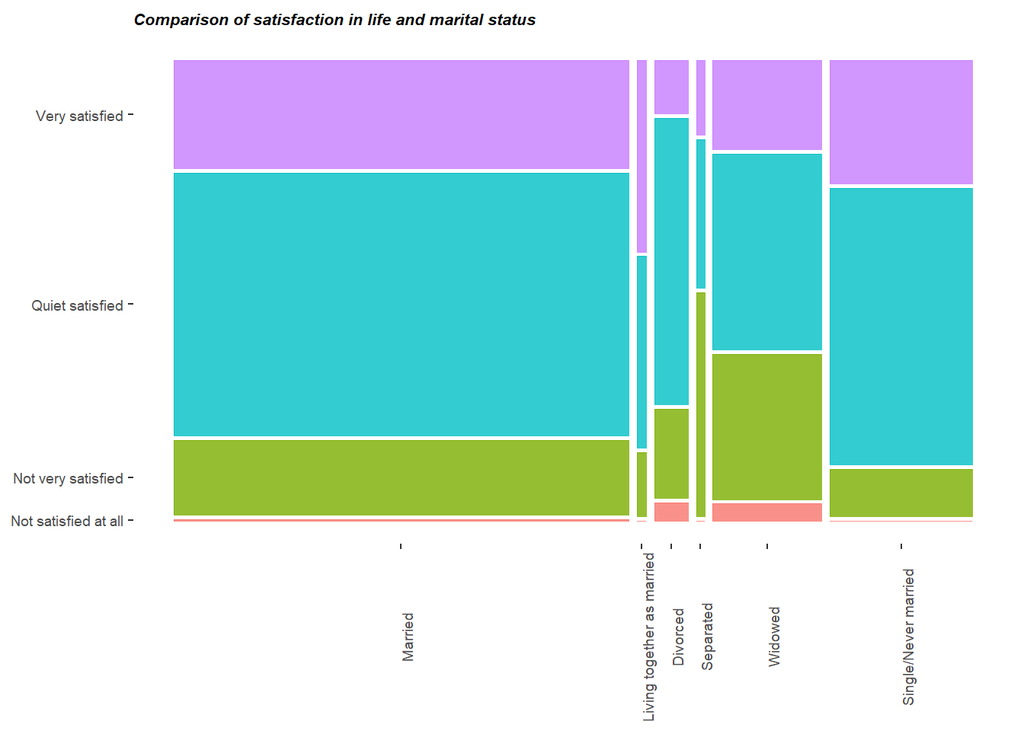

The distribution of “very satisfied” people is quiet similar to the one seen in the previous plot. The same counts for the “not very” or “not satisfied at all”, with widowed people making up the largest population.

### 2.2.5 Additional variables

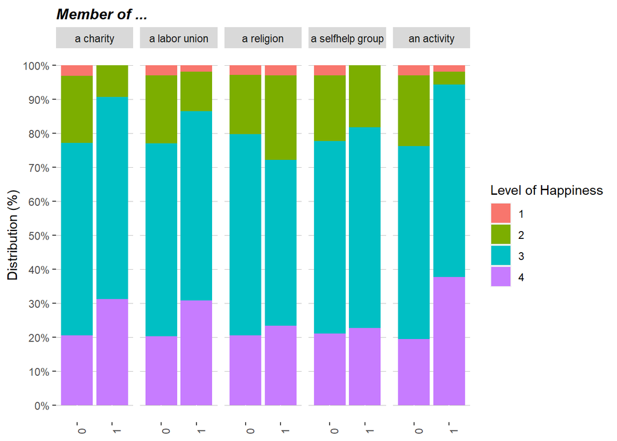

These additional variables also allow a little bit of insight into the data. Starting off with charitable causes we can see that those who mentioned being a member of a charitable organisation reported to be quite happy or very happy more often.

Being a member of a labor union also seems to have a certain connection to happiness as union members more often reported to be quite or very happy as opposed to non-members.

Interestingly, being a member of a religious organisation doesn’t seem to increase happiness for all participants. It can be observed that those who are religious more often reported to be not very happy but at the same time religious respondents more often reported to be very happy. One way of interpreting this would be to assume that being religious could have a diverging effect on people and either increase or decrease their happiness according to some other external variable.

Looking at the variable of being a member of a self-help group, the graphs don’t diverge as much as for other variables. Those who are members of a self-help group have a little more frequently reported to be quite happy than those who are not, but the effect is very small.

Finally, being a member of an activity. This seems to be connected to the effect of happiness as those who have reported to be member of any sort of activity rarely mentioned to be not very happy or not at all happy. Over 90% of respondents who mentioned to be member of an activity reported to be either very or at least quite happy.

# 3 Social Capital

> The literature shows that Social Capital is an important factor for increasing the level of SWB. For the trust dimension of social capital you may use the variable asking whether people can generally be trusted or not, for the weak ties dimension you could use the sum of the variables asking whether one is a member of … For the following section, we shall have a look at how the subjective well-being (SWB), namely general happiness and life satisfaction, are linked to Social Capital In order to take a closer look at the SWB, we shall take the term of the Social Capital into account. The literature shows that Social Capital is an important factor for increasing the level of SWB. But first of all, what is Social Capital? Social capital can be seen as “a positive product of human interaction” (investopedia.com). While it can not be owned by somebody, it is the result of connections between individuals within social networks. Social capital can be seen as a base pillar for the effective functioning of social groups. The absence of Social capital can mislead a group of people to not achieve a common goal or purpose.

Despite its undeniable value for any group of individuals, there is no consensus on how social capital can be measured directly. This leads to the conclusion, that social capital can only be expressed through other indicators. The European Value Study (EVS) includes several indicators which can help to determine a countries Social Capital. In the following, we are going to consider trust as a key dimension for social capital. The EVS sees the trust variable as an indication whether most people can be trusted or not. in particular, the people participating in the survey get asked the following question: Generally speaking, would you say that most people can be trusted or that you can’t be too careful in dealing with people? The answer is then separated into two possible answers (1) “Most people can be trusted” and (2) “Can’t be too careful”. In the following diagram, we are going to provide an overview of the responses of the qualitative variable.

The following table depicts the distribution of the two levels of trust in Romania

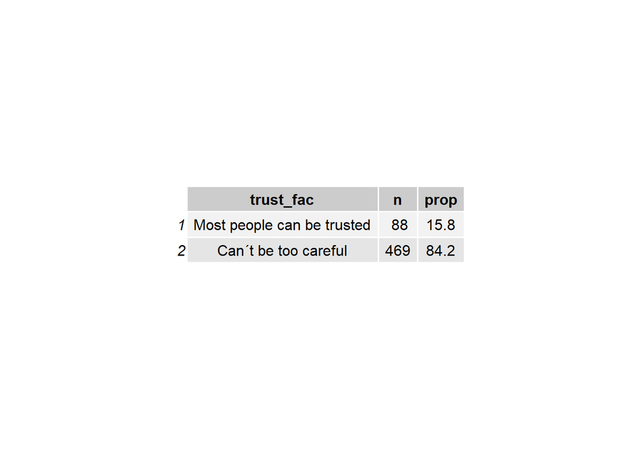

The following graph provides an overview on how trust and happines in life, as well as trust and satisfaction are eventually linked.

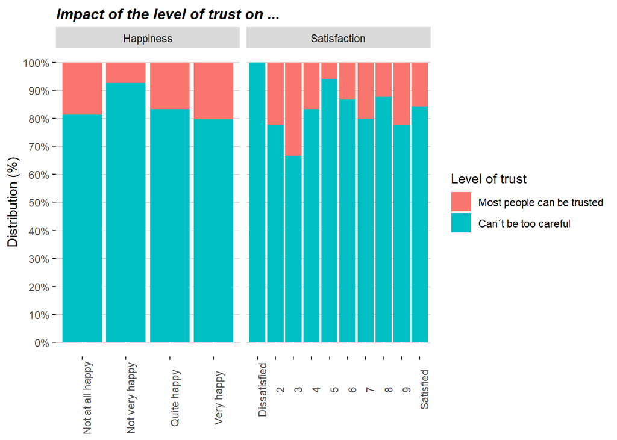

Looking at the graph, it is hard to establish a clear trend within the data. Starting with the “Happiness” part of the diagram, it can roughly be said, that those who are very or quite happy with their lives tend to trust their fellow citizens more on average.

Besides the trust factor, analyzing “weak ties” can also help to get an impression of the Social Capital among the Romanian people. The term weak ties implies connections among individuals which one does not know very well, but by whom one is surrounded on a regular basis. In the EVS, the interviewers asked the participants weather they are a member of various groups. Let us therefor first have a very general overview of how the membership in any group can have on happiness and or life satisfaction. *Note: for a better overview, the level of satisfaction has been grouped into 1: ‘Not satisfied at all’, 2-5: ‘Not very satisfied’, 6-9: ‘Quite satisfied’, 10: ‘Very satisfied’.*

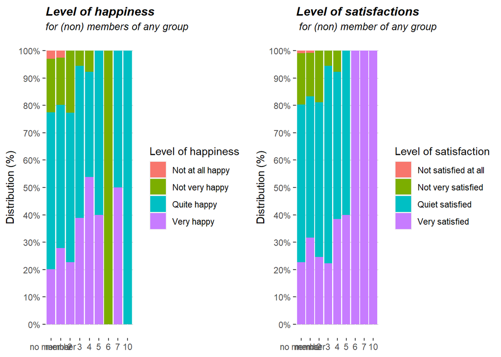

It can be seen, that on average members of any given organisation or institution are happier and more satisfied, than individuals who are not. This effect doesn’t seem to change when looking at general happiness or life satisfaction.

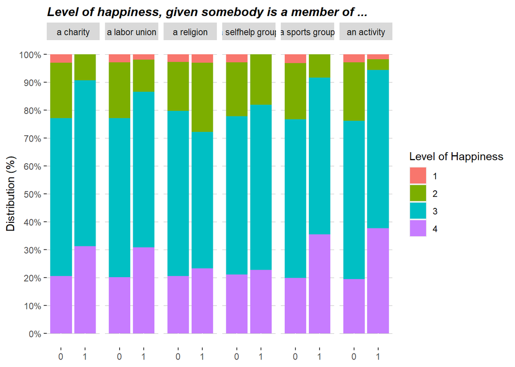

Starting off with charitable causes we can see that those who mentioned being a member of a charitable organisation reported to be quite happy or very happy more often. Being a member of a labor union also seems to have a certain connection to happiness as union members more often reported to be quite or very happy as opposed to non-members.

Interestingly, being a member of a religious organisation doesn’t seem to increase happiness for all participants. It can be observed that those who are religious more often reported to be not very happy but at the same time religious respondents more often reported to be very happy. One way of interpreting this would be to assume that being religious could have a diverging effect on people and either increase or decrease their happiness according to some other external variable.

Looking at the variable of being a member of a self-help group, the graphs don’t diverge as much as for other variables. Those who are members of a self-help group have a little more frequently reported to be quite happy than those who are not, but the effect is very small.

Looking at sports groups, the effect on happiness seems to be surprisingly large. Those who reported to be members of sports groups are to a large extent either very happy or at least quite happy overall. Those two groups together constitute over 90% of those reporting to be member of a sports group or team.

Finally, being a member of an activity. This seems to be connected to the effect of happiness as those who have reported to be member of any sort of activity rarely mentioned to be not very happy or not at all happy. Over 90% of respondents who mentioned to be member of an activity reported to be either very or at least quite happy.

It can be assumed, that this effect is similar to the one observed for sports groups, as the graph for overall activities strongly mirrors the one for sports groups.

We assume that weak ties also appear in the neighborhood. Since neighbors are in some way silent, but steady companions, we find it highly important to look at what impact a certain neighborhood can have on the the trust the questioned people have in them.

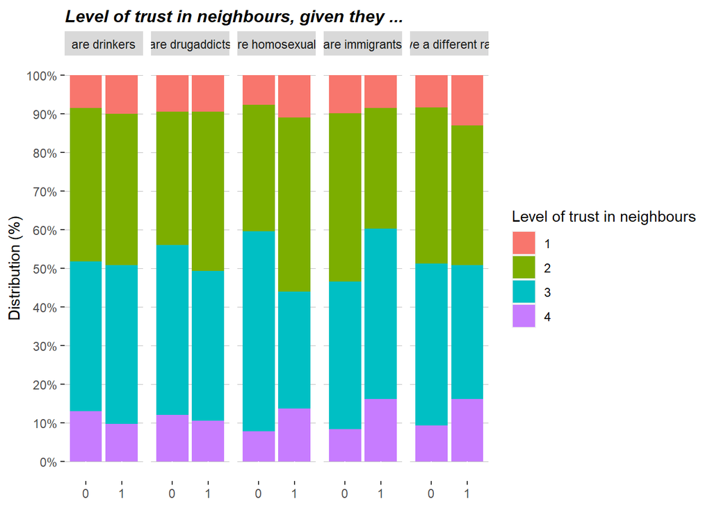

Starting off with drinking neighbors. To most people it doesn’t really seem to matter if their neighbors are drinkers or not. The two graphs barely differ from each other. There is a small group of respondents that responds with “trust somewhat” as opposed to “trust completely” if their neighbors are drinkers, but the effect is too small to be investigated further.

Being a drug addict however, seems to have a more significant effect. The picture is similar to drinking, but a larger percentage of respondents reports to not trust their neighbors very much if they are drug addicts.

The case for homosexuality however is an interesting one. There seems to be a rather large group of respondents that chooses not to trust their neighbors very much as opposed to trusting them somewhat, if they happen to be homosexuals. On the other hand, there is also a group of respondents which increase the trust in their neighbors from trusting them somewhat to trusting them completely.Having homosexual neighbors therefore seems to have a split effect on the Romanian citizens, depending on an external variable.

Having immigrant neighbors seems to enhance the trust that Romanian citizens have in them. This seems to be a uniform effect for all citizens. There is a larger percentage of citizens reporting to trust their neighbors completely as well more citizens trusting them at least somewhat if they happen to be immigrants.

Neighbors having a different race seems to polarize the Romanian people to a small but visible extent. There is a larger percentage of respondents reporting to trust their neighbors completely as well as a larger percentage of citizens not trusting their neighbors at all if they have a different race.

Furthermore, weak ties also appear within a religion. Individuals which share similar interests, such as the same god, implicitly see each other on a regular basis when attending a church service. The following two mosaic plots shall provide an overview on how the attendance of a church service might affect the level of SWB, as we assume, that weak ties have a positive effect on the Social capital and therefor on the level of SWB.

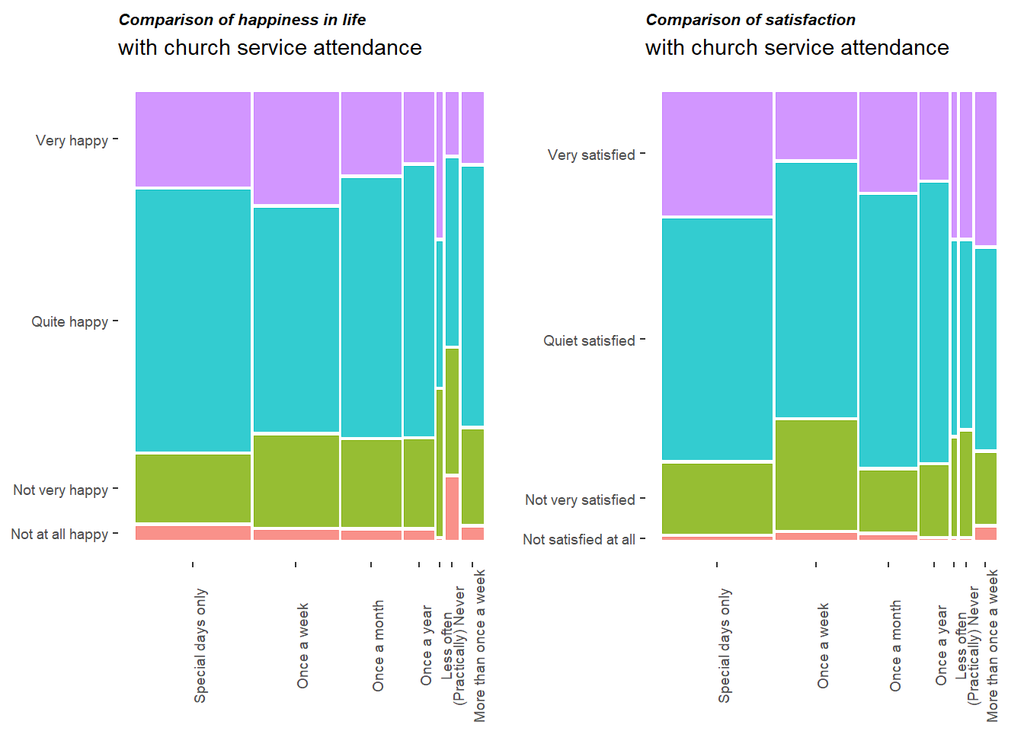

There doesn’t seem to be a clear connection between church attendance and happiness in life or life satisfaction. The mosaic patterns don’t differ very much from each other, with one exception. It can be seen, that those who practically never attend church report to be not very happy a little more frequently than those who (for instance) attend church more than once a week. This effect however is not visible when switching to life satisfaction. Overall, the effect doesn’t seem to be strong enough to speculate a connection between church attendance and happiness or satisfaction.

# 4 Principal Component Analysis

> Try to find appropriate components for the political interest and attitude dimension, e.g. run a PCA using the variables “Interested in politics”, “Satisfaction with the political system”, “Having a democratic political system”, “Importance of democracy”, …

## 4.1 overview of variables

The key variable for our analysis is going to be the E023 - Interest in politics (interest_politics) variable. However, the survey offers more questions in regards to the attitude towards politics. In order to avoid misunderstanding, we want to give a quick overview of what the variables mean.

| **id** | **variable** | **explaination** |
| --- | --- | --- |
| E023 | intrests_politics | How interested would you say you are in politics? |
| E025 | politics_petition | Signing a petition |
| E026 | politics_boycott | Joining in boycotts |
| E027 | politics_demo | Attending lawful demonstrations |
| E028 | politics_strikes | Joining unofficial strikes |
| E111_01 | politics_satisfaction | Satisfaction with the political system |
| E117 | politics_democracy | Having a democratic political system |
| E235 | importance_democracy | Importance of democracy |

The variables in the following graph are going to be key elements in the following principal components analysis.

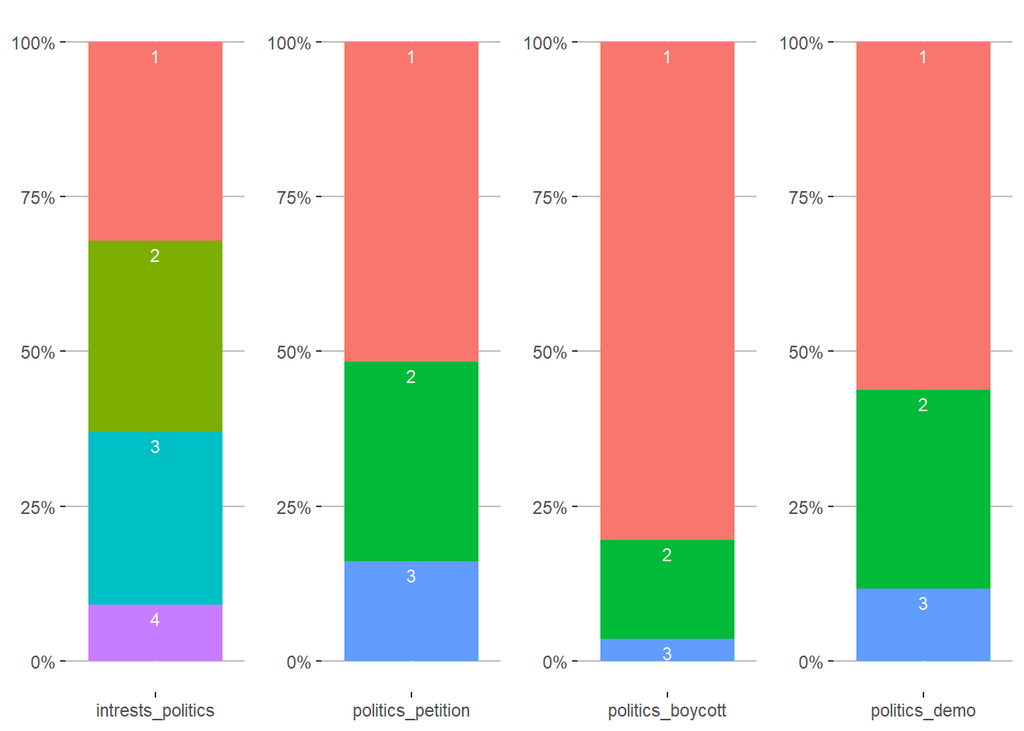

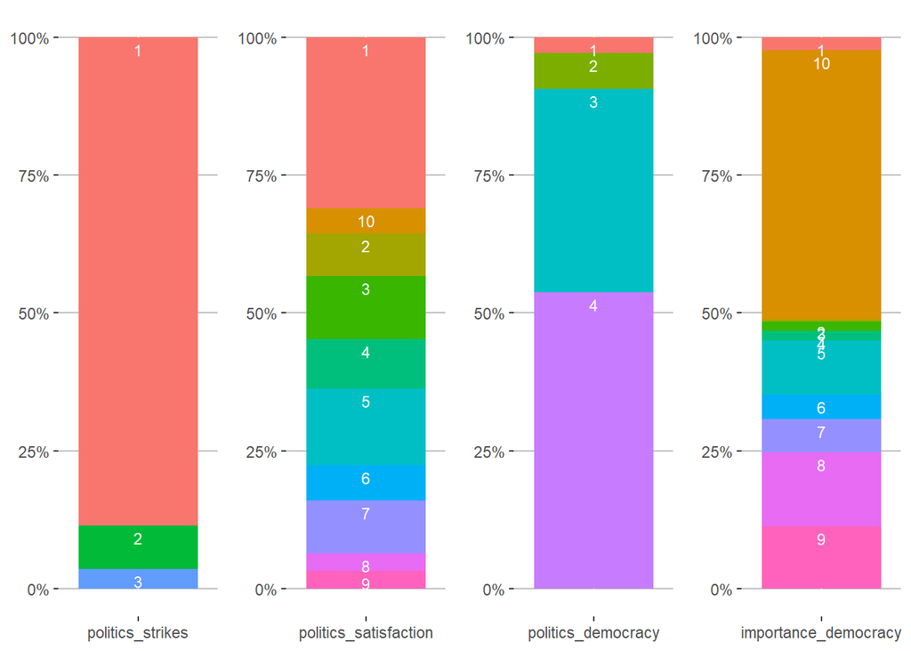

The graphs indicate a first rough overview of the political climate in Romania. For more than half of the people are not very interested to not at all interested in politics, which reflects in taking political actions. Only few people have signed a petition, joined a boycott, joined a lawful demonstration or even joined an unofficial strike. Nevertheless, a slight majority sees democracy as a very good idea, and highlight the importance of democracy.

The following tables provide an overview of the exact scaling for the variables. We decided to scale the variables in a way, that a higher number indicates a more positive attitude/ a higher involvement towards the variable.

```
## $intrests_politics
## [1] "[1] Not at all interested" "[2] Not very interested"
## [3] "[3] Somewhat interested"   "[4] Very interested"
##
## $politics_petition
## [1] "[1] Would never do" "[2] Might do"       "[3] Have done"
##
## $politics_boycott
## [1] "[1] Would never do" "[2] Might do"       "[3] Have done"
##
## $politics_demo
## [1] "[1] Would never do" "[2] Might do"       "[3] Have done"
##
## $politics_strikes
## [1] "[1] Would never do" "[2] Might do"       "[3] Have done"
##
## $politics_satisfaction
##  [1] "[1] Not satisfied at all"  "[2] 2"
##  [3] "[3] 3"                     "[4] 4"
##  [5] "[5] 5"                     "[6] 6"
##  [7] "[7] 7"                     "[8] 8"
##  [9] "[9] 9"                     "[10] Completely satisfied"
##
## $politics_democracy
## [1] "[1] Very bad"    "[2] Fairly bad"  "[3] Fairly good" "[4] Very good"
##
## $importance_democracy
##  [1] "[1] Not at all important"  "[2] 2"
##  [3] "[3] 3"                     "[4] 4"
##  [5] "[5] 5"                     "[6] 6"
##  [7] "[7] 7"                     "[8] 8"
##  [9] "[9] 9"                     "[10] Absolutely important"
```

## 4.2 Analysis

In order to find groups in the data, we decided to plot the dimensions among each other. In the following section, one can see a Screeplot in 4.2.1, and the different scatterplots for the first two principal components. We neglect comparing the 4th and the 5th principal component, since we find the variance covered, to be too low.

### 4.2.1 Screeplot

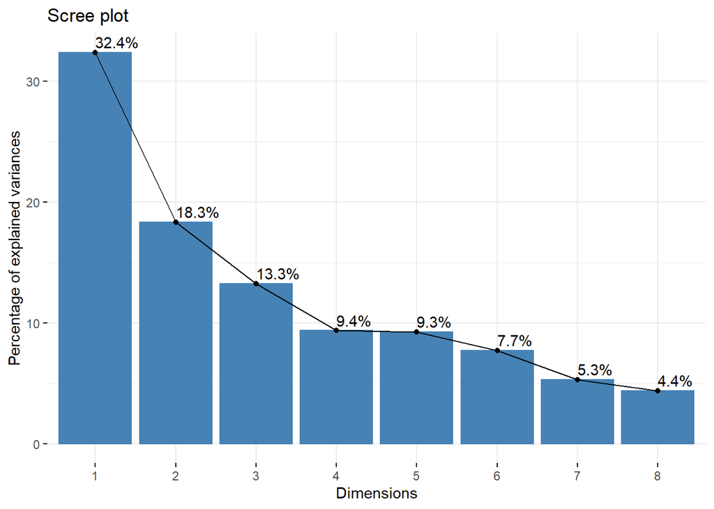

### 4.2.2 scatterplot for PC1

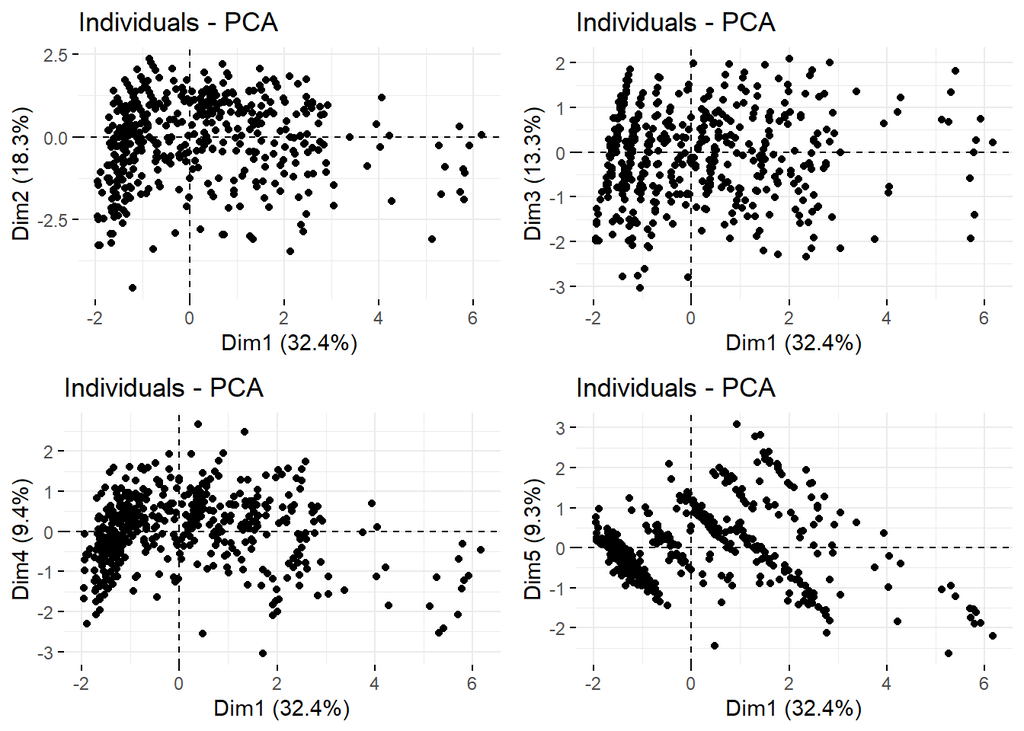

From comparing these graphs, we can see, that there is a clear group forming for the first two dimensions. However, a similar group forms for the first and the fourth dimension.

### 4.2.3 scatterplot for PC2

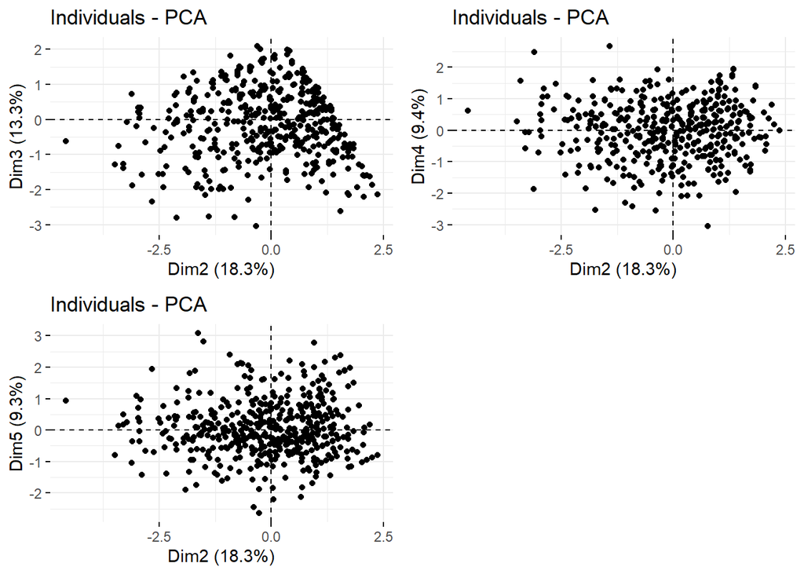

The second and the third dimension seem to characterize a group as well.

## 4.3 Biplots

In order to identify what characterizes the groups, we want to provide some Biplots, which seemed to give us some information about the groups we might find in the data, without neglecting the level of variance we cover with the analysis.

When interpreting the biplots, one also need to take into account, how the data is scaled. For instances, the scaling of the data will be specifically noted. However, looking at the biplots between PC 1 and 2 as well as 1 and 4 a couple things become clear which are very interesting to note.

### 4.3.1 Biplot PC1&PC2

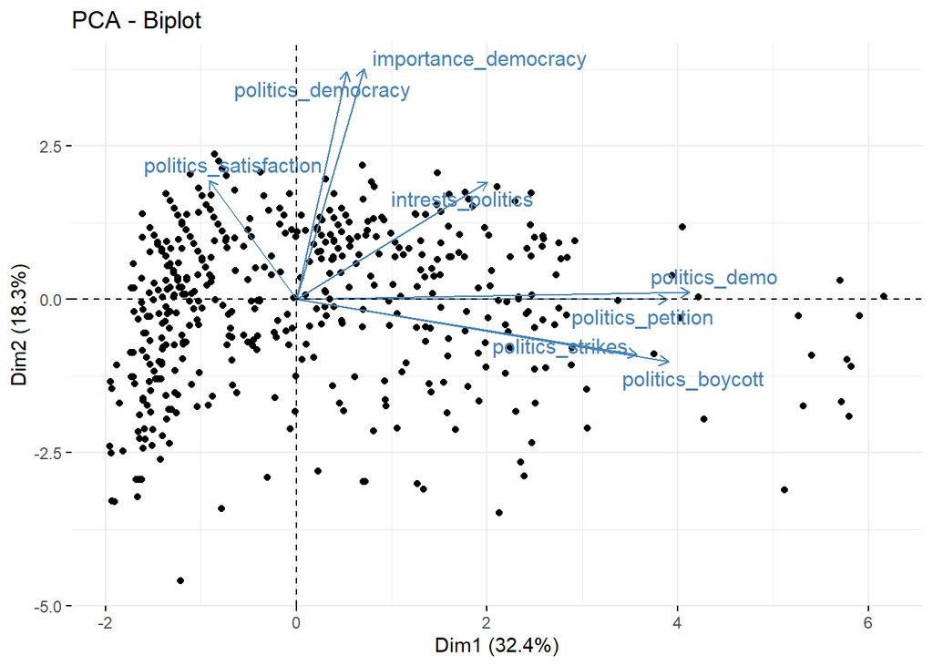

In the Biplot between the first and the second principal component, we can see that the importance of democracy is positively correlated to the attitude of having a democratic system. Importance_democracy measures the importance, that a given respondent attributes to the concept of democracy as a whole. This is measured on a scale from 1-10 with 10 attributing the highest level of importance to the concept of democracy. That being said, it makes sense, that a respondent who thinks highly of democracy would attribute a lot of importance to the concept of democracy while simultaneously being convinced that living in a democracy is an important thing.

The remaining vectors rather form a nearly 90 degree angle towards the two mentioned vectors. Therefor it can be said, that the importance of democracy or the satisfaction with the democratic system is uncorrelated to whether somebody has attended a boycott, a strike, or a demonstration.

The interests in politics seems to also play a role in the importance for democracy, since they are positively correlated (same counts fo the attitude towards a democratic system as a whole)

### 4.3.2 Biplot PC1&PC4

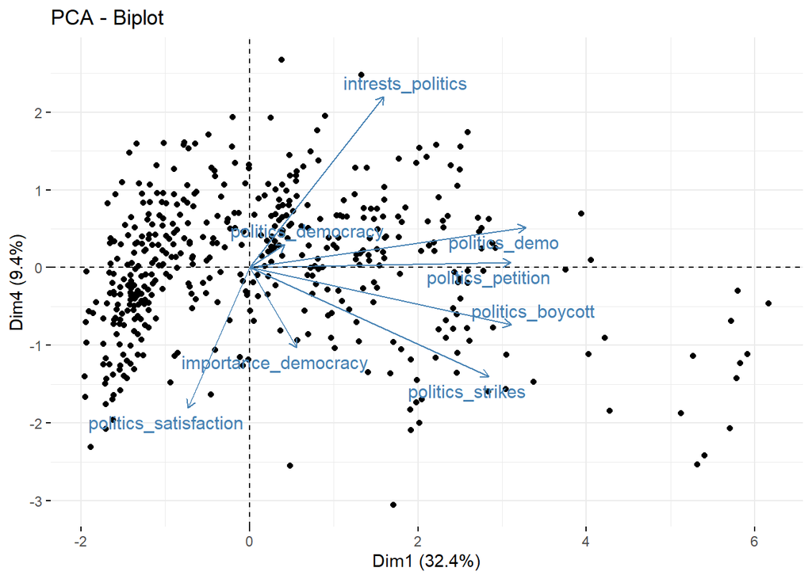

# 5 Further Weak Ties

The following plot shall give an overview of the distribution on how many people are acutally in a membership.

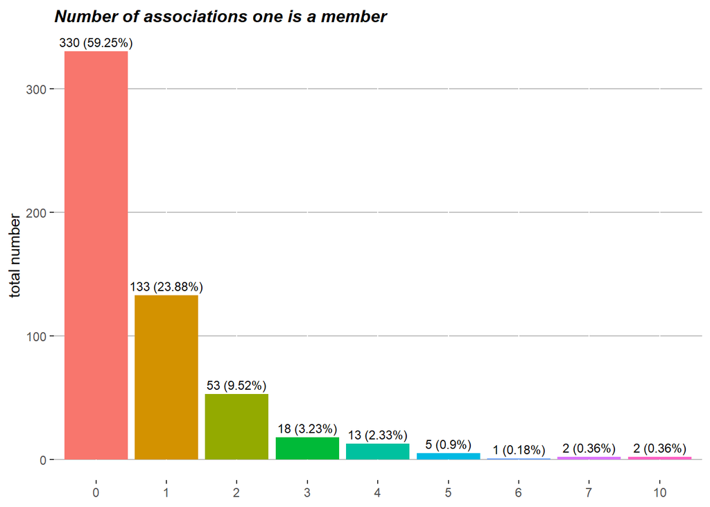

As one can see from the distribution of number of memberships, it does not make sense to keep the total number memberships as a variable, since the wide majority is not even in a single organization. Nevertheless, knowing this also helps for the further analysis. We can now add the variable “are you member in at least one organisation?”. Doing so includes the variable of activities that respondents may or may not be part of in a more reasonable way. Let us have a look an the distribution of the dummy variable then.

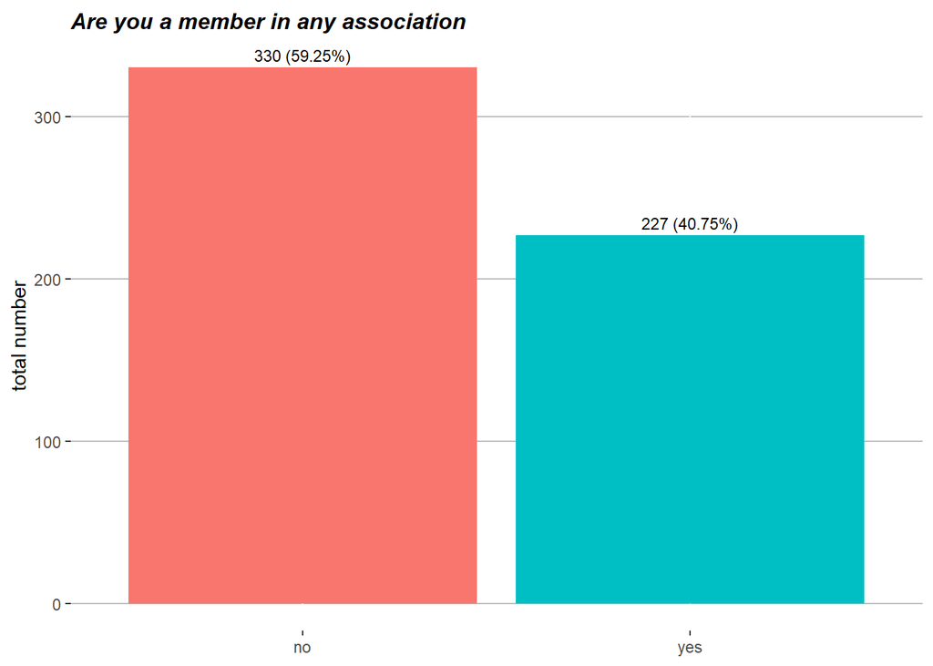

Looking at the variable of activities as a binary “are you a member of any of these organisations” variable seems to make more sense since it splits the dataset into two comparable groups. Let us therefore consider, how this weak tie influences the happiness and the life satisfaction of the Romanians.

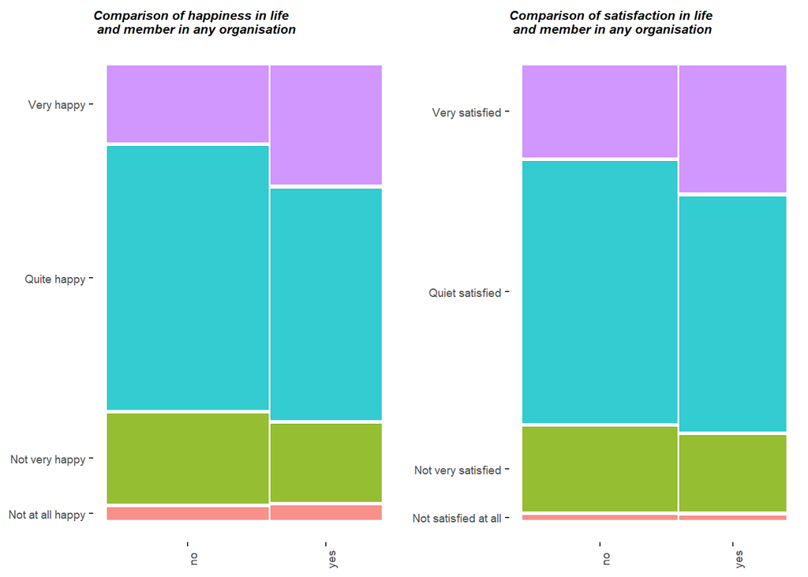

The impact that being a member of any organisation has on life satisfaction or happiness of the Romanian population is pretty similar. For both cases we see a visible, but not overwhelming increase of respondents that report to be “very happy”. For all else, there doesn’t seem to be a large change in responses.

This puts the decision to include the variable into perspective since the impact that it has on the responses seems to be rather limited. After consideration, it might be better to omit the variable of activity membership for the case of Romania since the influence seems to be rather limited.

However, we followed an additional approach, which was categorizing the membership variables into active memberships, and rather inactive memberships. The following table provides an overview of our active organisations, where we assume people to have weak ties.

| **variables for active memberships** |
| --- |
| Belong to religious organization (given a person attends church at least once a week) |
| Belong to edocation, arts, music or cultural activites |
| Belong to venservation, the environment, ecology, animal rights |
| Belong to sports or recreation |
| Belong to humanitarian or charitable organization |
| Belong to self-help group, mutual aid group |

This leaves us with 153 Romanians in the sample. Let us have a look at what this means on happiness and satisfaction.

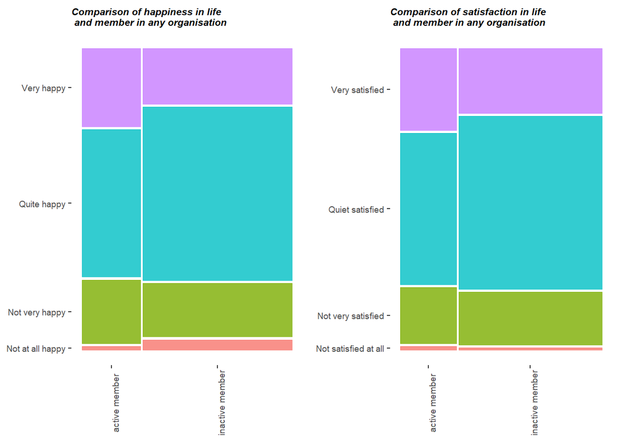

Here we can see a similar result to the previous plot, however, we believe, that the variable “are you an active member of an organisation” is much more reliable in regards to evaluating weak ties. However, even when only considering the memberships considered to be more active, the effect on happiness or satisfaction still remains marginal. As a consequence, we will omit the variable of membership in further analyses.

The next variable we will have a look at is the importance of friends. This can be seen as another weak tie as those who value the friends they have made in a certain area can be expected to be better integrated in their social system and be overall more content with their living situation. Let’s start by looking at the overall distribution for the Romanian people:

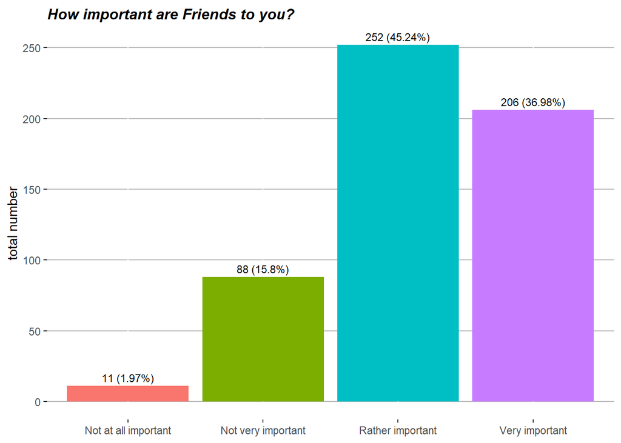

The barplot shows, that most of the Romanian respondents seem to place at least a certain bit of importance on their friends. Most of the respondents stated that friends are “rather important” to them. Closely following up is the group for which friends are “very important”. Taking these groups together, we can estimate that around 82.22% of the Romanian respondents place at least a certain bit of value on their friends. This leads us to speculate that this variable might be relevant to include in further analysis. However, in order to be sure whether we should consider this variable further, let’s look at how the importance of friends impacts life satisfaction and overall happiness

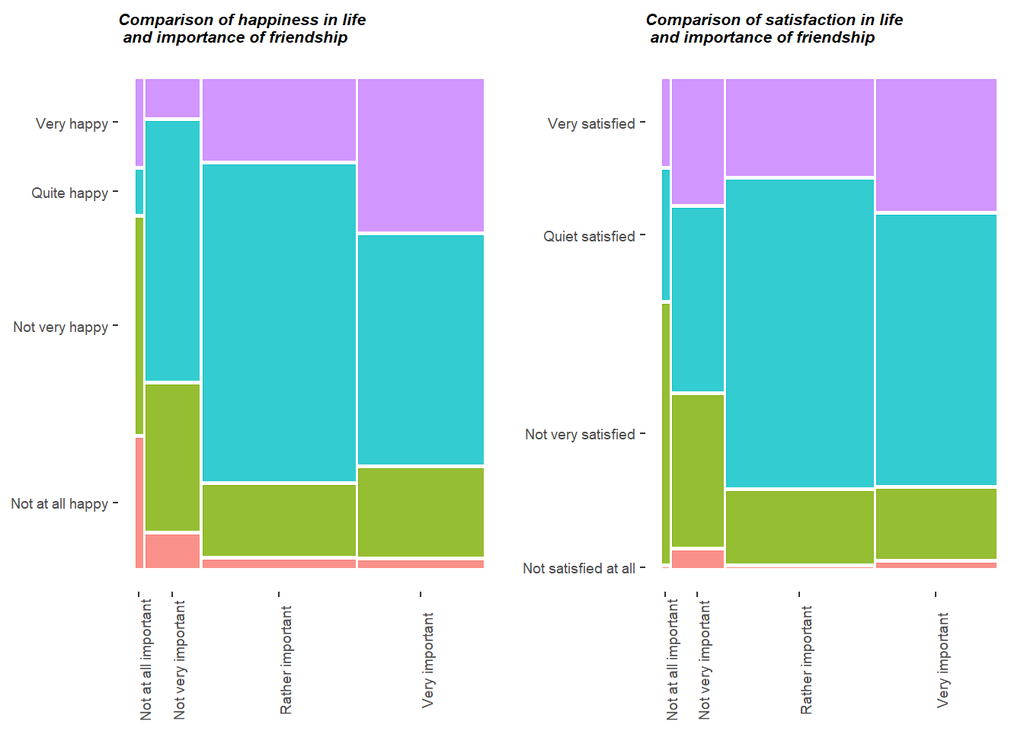

Starting with the impact that the importance of friends has on happiness, we can see that the more important friends get, the larger are the percentages of respondents claiming to be quite or very happy. However, keeping the previous illustration in mind, we need to remember that the group sizes for friend importance were rather asymmetrical, with much more respondents stating that friends would be rather important. The overall theme however still seems to be that the more important friends are to a respondent, the more happy they appear to be. We can observe a similar effect when looking at life satisfaction. The effects previously mentioned can still be seen here, although slightly less pronounced. When comparing the groups it shows that those who consider their friends to be rather or very important also seem to respond being quite or very satisfied with their lives. And although the effects might not be as pronounced as we might have hoped, we still think it pays off to keep this variable in mind when proceeding in the analysis.

# 6 Strong Ties

The variable “Important in life: Family” indicates another strong tie. In order to get an overview of the variable, let us have a look at the distribution.

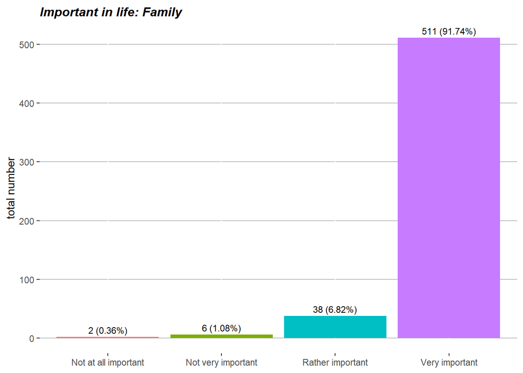

As we can see from the distribution, the vast majority of the people in Romania (91%) see their family as “very important”. This is for sure not a bad thing for the Romanian people, however it is not very helpful for our further analysis, since the distribution is very unequal. Due to the low power that any analysis with this variable would have, the importance of family as a proxy for strong ties will be omitted in further analyses because of its asymmetrical distribution.